# HW7_syQiu

Author

Shuyi Qiu

Load packages and dataset

```r
library(gssr)
library(tidyverse)
library(infer)

gss18 <- gss_get_yr(2018)
```

# 7.1.1 Probabilities

```r
d <- gss18 |>
  select(sex, attend, polviews) |>
  haven::zap_missing() |>
  mutate(sex = as_factor(sex)) |>
  haven::zap_labels() |>
  drop_na() |>
  mutate(
    weekly = factor(ifelse(attend >= 7, 1L, 0L), levels = c(0L, 1L), labels = c("LT Weekly", "Weekly")),
    conservative = factor(ifelse(polviews >= 5, 1L, 0L), levels = c(0L, 1L), labels = c("Non-Conservative", "Conservative"))
  )

table(d$weekly, d$conservative)
```

```
            Non-Conservative Conservative
  LT Weekly             1243          495
  Weekly                 257          240
```

```r
table(d$weekly)
```

```
LT Weekly    Weekly
     1738       497
```

```r
table(d$conservative)
```

```
Non-Conservative     Conservative
            1500              735
```

1. The probability that a person attends religious services weekly.

   $Pr(Weekly)=\frac{497}{2235}=$ 0.2224
2. The probability that a person does not attend religious services weekly.

   $Pr(LT\ Weekly)=\frac{1738}{2235}=$ 0.7776
3. The probability that a person is conservative, given that they attend religious services weekly.

   $Pr(Conservative|Weekly)=\frac{240}{497}=$ 0.4829
4. The probability that a person attends services weekly, given that they are conservative.

   $Pr(Weekly|Conservative)=\frac{240}{735}=$ 0.3265
5. The probability that a person is conservative given that they do not got to church weekly

   $Pr(Conservative|LT\ Weekly)=\frac{495}{1738}=$ 0.2848
6. The probability that a person is conservative and also attends religious services weekly.

   $Pr(Weekly\&Conservative)=\frac{240}{2235}=$ 0.1074
7. The probability that a person is non-conservative but does not attend religious services weekly.

   $Pr(LT\ Weekly\&Non-Conservative)=\frac{1243}{2235}=$ 0.5562
8. The joint probability of W and C, assuming it is independent:

   $Pr(Weekly\&Conservative)=Pr(Weekly)*Pr(Conservative)=\frac{497}{2235}*\frac{735}{2235}=$ 0.0731

# 7.1.2 Table

```r
f <- gss18 |>
  select(happy, marital) |>
  haven::zap_missing() |>
  haven::zap_labels() |>
  drop_na() |>
  mutate(
    married = factor(ifelse(marital == 1, 1L, 0L), levels = c(0L, 1L), labels = c("Not married", "Married")),
    happyn = factor(ifelse(happy <= 2, 1L, 0L), levels = c(0L, 1L), labels = c("Not happy", "Happy"))
  )

table(f$married, f$happyn)
```

```
              Not happy Happy
  Not married       275  1070
  Married            61   936
```

```r
table(f$married)
```

```
Not married     Married
       1345         997
```

```r
table(f$happyn)
```

```
Not happy     Happy
      336      2006
```

Redo the exercise in 7.1.1

1. The probability that a person is happy.

   $Pr(happy)=\frac{2006}{2342}=$ 0.8565
2. The probability that a person is not happy.

   $Pr(not\ happy)=\frac{336}{2342}=$ 0.1435
3. The probability that a person is married, given that they are happy.

   $Pr(married|not\ happy)=\frac{61}{336}=$ 0.1815
6. The probability that a person is both happy and married.

   $Pr(happy\&married)=\frac{936}{2342}=$ 0.3997
7. The probability that a person is not happy and not married.

   $Pr(not\ happy\&not\ married)=\frac{275}{2342}=$ 0.1174
8. The joint probability that a person is happy and married, given that they are independent.

   $Pr(happy\&married)=Pr(happy)*Pr(married)=\frac{2006}{2342}*\frac{997}{2342}=$ 0.3646

# 7.2.1 Four Dependence

## 1. Difference in Probabilities

$Pr(Weekly|Conservative)-Pr(Weekly|Non-conservative)=\frac{240}{735}-\frac{257}{1500}=$ 0.1552

## 2. Relative Risk Ratio

$\frac{Pr(Weekly|Conservative)}{Pr(Weekly|Non-conservative)}=\frac{\frac{240}{735}}{\frac{257}{1500}}=$ 1.9058

## 3. Odds Ratio

Odds of that a conservative person goes to religion services weekly = $\frac{240}{495}=$ 0.4848

Odds of that a non-conservative person goes to religion services weekly = $\frac{257}{1243}=$ 0.2068

Odds ratio = $\frac{\frac{240}{495}}{\frac{257}{1243}}=$ 2.345

## 4. Log Odds Ratio

$log(Odds\ Ratio)=log(\frac{\frac{240}{495}}{\frac{257}{1243}})=$ 0.8523

# 7.2.2. Inference

## 1. Relative Risk Ratio

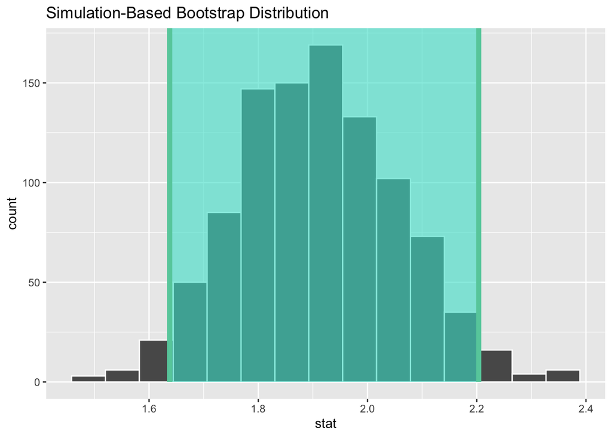

```r
boot_dist_d1 <- d |>
  specify(weekly ~ conservative, success = "Weekly") |>
  generate(
    reps = 1000, # Do 1000 times
    type = "bootstrap" # Draw sample where the sample size equals tot the input sample size with replacement
  ) |>
  calculate(stat = "ratio of props",
            order = c("Conservative","Non-Conservative"))

ci <- boot_dist_d1 |>
  get_confidence_interval(level = 0.95)

boot_dist_d1 |>
  visualise() +
  shade_ci(ci)
```

## 2. Odds Ratio

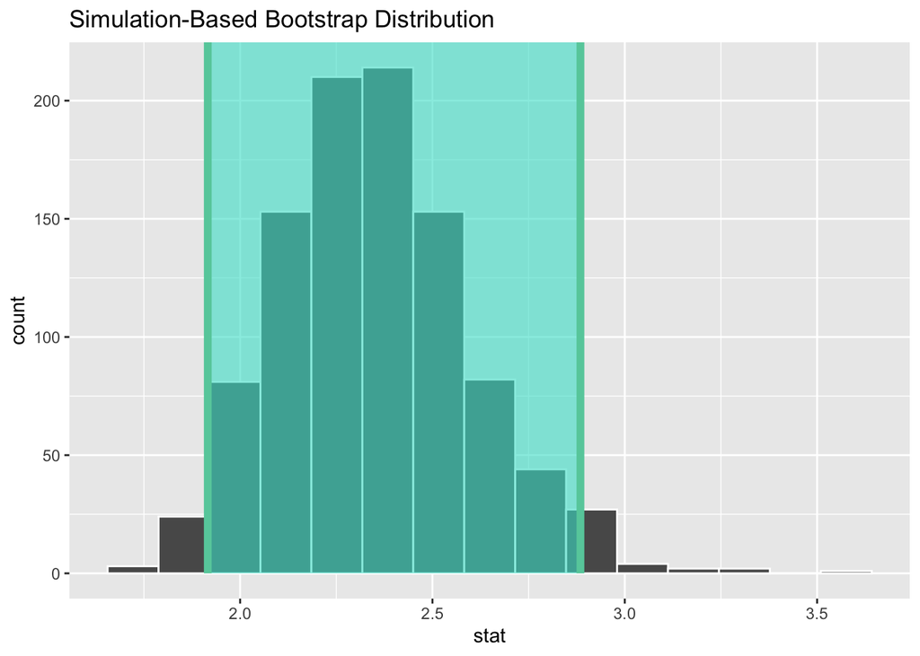

```r
boot_dist_d2 <- d |>
  specify(weekly ~ conservative, success = "Weekly") |>
  generate(
    reps = 1000, # Do 1000 times
    type = "bootstrap" # Draw sample where the sample size equals tot the input sample size with replacement
  ) |>
  calculate(stat = "odds ratio",
            order = c("Conservative","Non-Conservative"))

ci <- boot_dist_d2 |>
  get_confidence_interval(level = 0.95)

boot_dist_d2 |>
  visualise() +
  shade_ci(ci)
```

# 7.2.3 Four Dependence - My own example

## 1. Difference in Probabilities

$Pr(Happy|Married)-Pr(Happy|Not married)=\frac{936}{997}-\frac{1070}{1345}=$ 0.1433

## 2. Relative Risk Ratio

$Pr(Happy|Married)-Pr(Happy|Not married)=\frac{\frac{936}{997}}{\frac{1070}{1345}}=$ 1.1801

## 3. Odds Ratio

The odds that a married person is happy = $\frac{936}{61}=$ 15.3443

The odds that a person who’s not married is happy = $\frac{1070}{275}=$ 3.8909

The odds ratio = $\frac{\frac{936}{61}}{\frac{1070}{275}}=$ 3.9436

## 4. Log Odds Ratio

Log odds ratio = $log(\frac{\frac{936}{61}}{\frac{1070}{275}})=$ 1.3721

# 7.2.4 Sample Distribution - My own example

## 1. Relative Risk Ratio

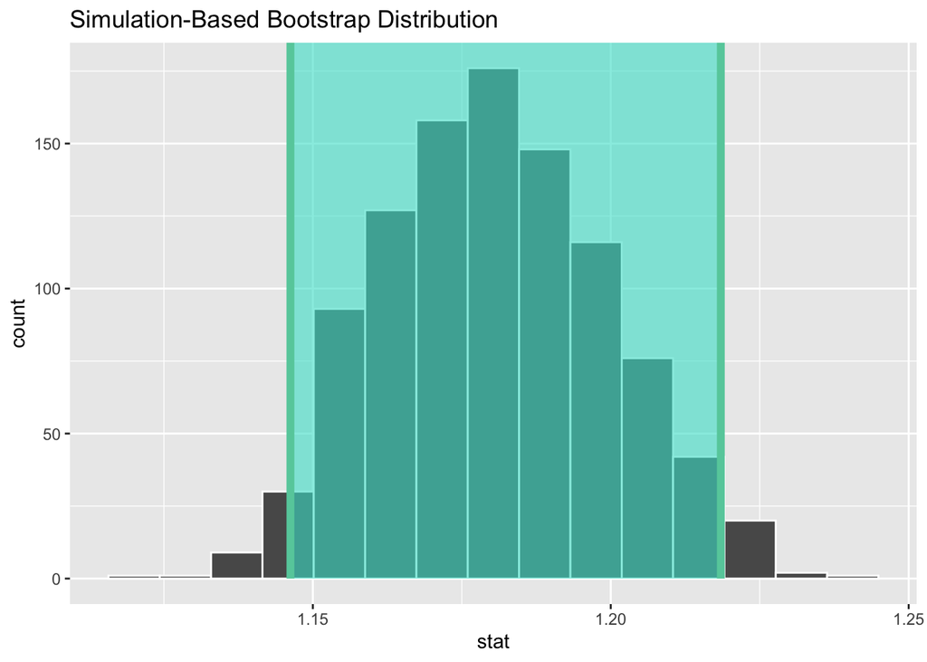

```r
boot_dist_f1 <- f |>
  specify(happyn ~ married, success = "Happy") |>
  generate(
    reps = 1000, # Do 1000 times
    type = "bootstrap" # Draw sample where the sample size equals tot the input sample size with replacement
  ) |>
  calculate(stat = "ratio of props",
            order = c("Married","Not married"))

ci <- boot_dist_f1 |>
  get_confidence_interval(level = 0.95)

boot_dist_f1 |>
  visualise() +
  shade_ci(ci)
```

## 2. Odds Ratio

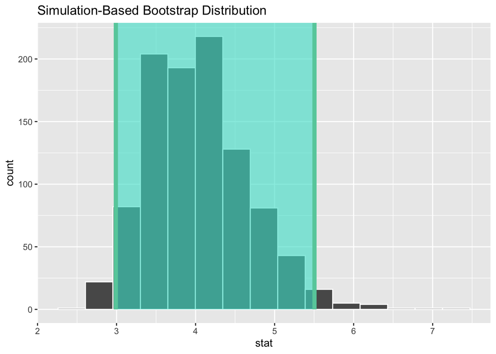

```r
boot_dist_f2 <- f |>
  specify(happyn ~ married, success = "Happy") |>
  generate(
    reps = 1000, # Do 1000 times
    type = "bootstrap" # Draw sample where the sample size equals tot the input sample size with replacement
  ) |>
  calculate(stat = "odds ratio",
            order = c("Married","Not married"))

ci <- boot_dist_f2 |>
  get_confidence_interval(level = 0.95)

boot_dist_f2 |>
  visualise() +
  shade_ci(ci)
```